# Predicting Patient No-Show Rates in Healthcare

Anastasia Moore

The purpose of the following document is to outline my approach and develop a model that predicts the patient’s probability of no-show (“Runnable Code” tab) and, based on my findings, give recommendations to the operating unit (“Executive Summary” tab).

## Executive Summary

Patient no-show is a relatively substantial problem as it results in inefficient resource utilization and poses a risk to the quality of health care services.[^1]

Historic data from the years 2015 - 2016 was used to find an optimal model that predicts no-show patients. 75% percent of the dataset was randomly assigned to model development, and 25% was assigned to validation. The predictive model was developed using logistic regression. From the training data, the optimal no-show threshold was determined to be 0.8. The final model presented an accuracy of 80.2%.

The most important predictors were prior no-shows and how many days in advance the appointment was scheduled.

For example, the plot below shows how the count of prior no-shows affects the proportion of the next appointment no-show:

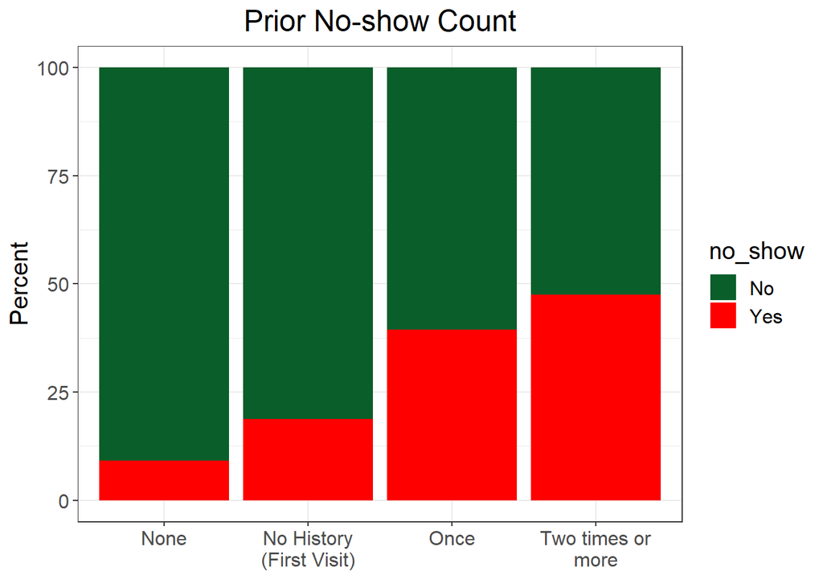

```r
#########################################################################################
#                                   Visualizations                                      #
#########################################################################################

#prior no-shows
plot_no_shows <- model_data %>%
  group_by(prior_noshow_group,no_show)%>%
  count()%>%
  group_by(prior_noshow_group)%>%
  mutate(percent = n/sum(n)*100,)%>%
  ungroup() %>%
  arrange(prior_noshow_group)  %>%
  arrange(percent)

plot_no_shows <- plot_no_shows[order(-plot_no_shows$percent),]

# ggplot(plot_no_shows, aes(y = n, x = fct_inorder(prior_noshow_group))) +
#   geom_bar(stat='identity', aes(fill = no_show))

ggplot(plot_no_shows, aes(y = percent, x = fct_inorder(prior_noshow_group))) +
  geom_bar(stat='identity', aes(fill = no_show))+
  labs(
    title = str_wrap("Prior No-show Count", width = 60),
    x = element_blank(),
    y = "Percent"
  )+
  theme(text=element_text(size=15),
        plot.title = element_text(hjust = 0.5))
```

Generally, the more no-shows there were in the past, the higher the chance of the next no-show. New patients have almost twice as large chances of not showing up for the appointment than the patients who have never missed an appointment before.

Also, the fewer days in advance an appointment was scheduled, the better chances of showing up:

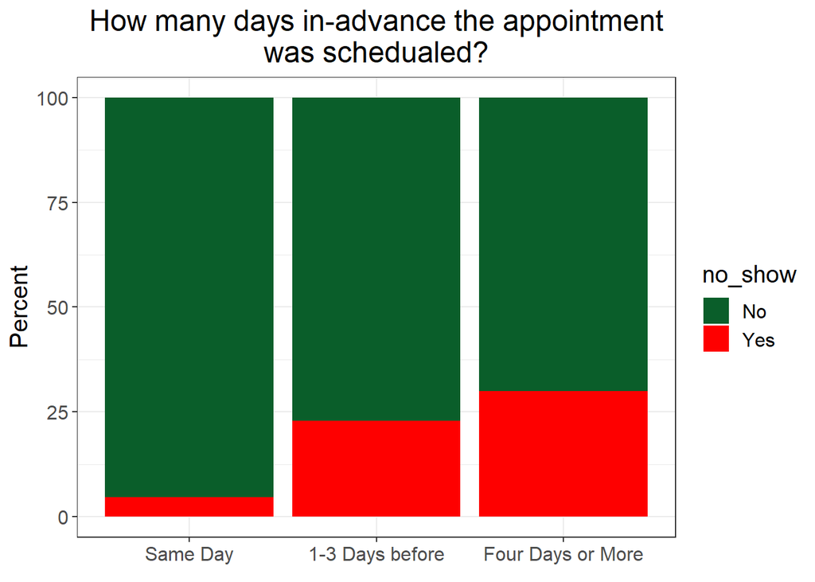

```r
#days_to_apptmt

plot_no_shows <- model_data %>%
  mutate(days_to_apptmt_group = factor(case_when(days_to_apptmt == 0 ~ "Same Day",
                                                 days_to_apptmt >= 4 ~ "Four Days or More",
                                                 days_to_apptmt >= 1 ~ "1-3 Days before"))) %>%
  group_by(days_to_apptmt_group,no_show)%>%
  count()%>%
  group_by(days_to_apptmt_group)%>%
  mutate(percent = n/sum(n)*100,)%>%
  ungroup() %>%
  arrange(days_to_apptmt_group)  %>%
  arrange(percent)

plot_no_shows <- plot_no_shows[order(-plot_no_shows$percent),]

# ggplot(plot_no_shows, aes(y = n, x = fct_inorder(days_to_apptmt))) +
#   geom_bar(stat='identity', aes(fill = no_show))

ggplot(plot_no_shows, aes(y = percent, x = fct_inorder(as.factor(days_to_apptmt_group)))) +
  geom_bar(stat='identity', aes(fill = no_show))+
  labs(
    title = str_wrap("How many days in-advance the appointment was schedualed?", width = 40),
    x = element_blank(),
    y = "Percent"
  )+
  theme(text=element_text(size=15),
        plot.title = element_text(hjust = 0.5))
```

Other important predictors included:

- age of patients:

  On average, patients younger than 50 tend to miss an appointment 6% more often than the older patients.
- hour of the day an appointment was scheduled:

  Generally, the earlier during the day the appointment was scheduled, the lesser chances of no-show.
- location ID:

  Some location IDs showed greater percentages of no-shows than others. More information on the meaning of those IDs is required for better understanding.
- text reminder:

  Sending a text increases the chances of missing an appointment by 11%.
- Medicaid status:

  Medicaid patients tend to miss an appointment 4% more often than non-Medicaid patients.

This model could help in the overbooking decision. One interesting approach is described in [this article](https://www.ncbi.nlm.nih.gov/pmc/articles/PMC4187098/#:~:text=This%20approach%20aims%20to%20overbook,time%2C%20overtime%20and%20total%20cost.). Further investigation and deployment are required to improve and validate the model.

Some unexpected results included the fact that reminder texts showed an increased chance of no-show. It is documented that reminders help decrease no-shows, but the content of the notification may have an affect on how successful it is. The article [Reducing No-Shows and Late Cancellations in Primary Care](https://scholars.unh.edu/cgi/viewcontent.cgi?article=1011&context=scholarly_projects) suggests some ways that this can be done effectively.

My recommendation would be to focus interventions on patients who have a history of no-shows and patients scheduling in advance, especially if those patients are on Medicaid. The article I mentioned above suggests that helping the patient understand the importance of their visit made them significantly more likely to show up.

## Runnable code

**Just the code:**

```r
#########################################################################################
#                                                                                       #
#               The purpose of the code below is to develop model(s) that               #
#                      predict patient’s probability of no-show.                        #
#                                                                                       #
#########################################################################################

#########################################################################################
#                               Set up the environment                                  #
#########################################################################################

library(tidyverse)
library(janitor)
library(data.table)
library(DataExplorer)
library(pander)
library(cowplot)

options(ggplot2.discrete.fill= c("#0a5e2a","#fe0000","#6c4e52","#d5a37b"))

theme_set(theme_bw())

#########################################################################################
#                                   Load the Data                                       #
#########################################################################################

data_orig <- read_csv("Medical_No_Shows_Candidate/Medical_No_Shows.csv")

#########################################################################################
#                                   Tidy the Data                                       #
#########################################################################################

#clean the names of each column
data <- data_orig %>%
  clean_names

#check types of each column
# str(data)

#fix the types
fix_type_data <- data %>%
  mutate_at(c(3,8:ncol(data)), as.factor)

#check types again to make sure the changes appeared appropriately
# str(fix_type_data)

#check NA's in each column
# sapply(fix_type_data, function(x) sum(is.na(x)))
#great, no NA's

#get the summary of each variable to see any weird values
# summary(fix_type_data)
#potential problems:
#1) age has some weird values of -1 and 115
#2) disability column has values of 2,3,4 that are not described in the "Data_ref" file
#3) some scheduled values occured later than the actual appointment?

#fix disability column to only show values of 0 and 1
fixed_data <- fix_type_data %>%
  mutate(disability = factor(ifelse(disability == 0, 0, 1)))

#delete rows with the appointment dates mistakes
fixed_data <- fixed_data %>%
  filter(!appointment_id %in% c("5715660", "5679978", "5664962", "5655637","5686628"))

#double check the changes
# summary(fixed_data)

#check how many unique values there are for each variable
# sapply(model_data, function(x) length(unique(x)))
#appointment_id is the key column (length of unique corresponds to the length of the data)


#########################################################################################
#                                Generate new features                                  #
#########################################################################################

model_data <- fixed_data %>%
  mutate(actual_weekday = factor(weekdays(appointment_day)),
         scheduled_weekday = factor(weekdays(scheduled_day)),
         scheduled_hour = hour(scheduled_day),
         days_to_apptmt = as.numeric(as.Date(appointment_day)-as.Date(scheduled_day)),
         no_show_bool = ifelse(no_show == "Yes", TRUE, FALSE)) %>%
  group_by(patient_id) %>%
  mutate(count_same_patient = n(),
         same_day_appt = ifelse(appointment_day %in% unique(appointment_day), FALSE,TRUE)) %>%
  ungroup() %>%
  mutate(patient_type = factor(ifelse(count_same_patient == 1, "New Patient", "Return Patient"))) %>%
  group_by(patient_id,appointment_day) %>%
  mutate(same_day_appt_count = n(),
         same_day_appt = ifelse(same_day_appt_count>1,TRUE,FALSE)) %>%
  ungroup() %>%
  group_by(patient_id) %>%
  arrange(appointment_day) %>%
  mutate(prior_no_show_bull = case_when(appointment_day == max(appointment_day) ~ FALSE,
                                        TRUE~no_show_bool),
         prior_no_shows = sum(prior_no_show_bull)) %>%
  ungroup() %>%
  mutate(prior_noshow_group = factor(case_when(patient_type == "New Patient" ~ "No History\n(First Visit)",
                                               prior_no_shows == 0 ~ "None",
                                               prior_no_shows == 1 ~ "Once",
                                               prior_no_shows >= 2 ~ "Two times or\nmore"))) %>%
  select(-c(prior_no_show_bull,no_show_bool,appointment_id))

#summary(model_data)


#########################################################################################
#                                 Create the model                                      #
#########################################################################################

#split the data into the training and testing sets (75% - train, 25% - test)
sample_size <- floor(0.75 * nrow(model_data))

# ensure the results are repeatable
set.seed(123)
train_ind <- sample(seq_len(nrow(model_data)), size = sample_size)

train <- model_data[train_ind, ]
test <- model_data[-train_ind, ]

#create the model
model <- glm(no_show ~sms_received+prior_no_shows+age
             +days_to_apptmt+scheduled_hour+location_id+medicaid_ind,
             family = binomial, data = train)
summary(model) %>% pander()

#########################################################################################
#                                   Test the model                                      #
#########################################################################################

test_response <- predict(model, test, type = "response")

test$test_response <-test_response

evaluate <- test %>%
  mutate(classification = ifelse(test_response > .8, "Predicted Yes", "Predicted No"))


(result <- table(evaluate$no_show, evaluate$classification))

#percent correctly classified:
pcc<- (result[1,1] + result[2,2]) / (result[1,1] + result[1,2] + result[2,1]+result[2,2])

paste0(round(pcc*100,2),"%")
```

**Explanation of the code:**

### Load the Data

```r
#########################################################################################
#                               Set up the environment                                  #
#########################################################################################

library(tidyverse)
library(janitor)
library(data.table)
library(DataExplorer)
library(pander)
library(cowplot)

options(ggplot2.discrete.fill= c("#0a5e2a","#fe0000","#6c4e52","#d5a37b"))

theme_set(theme_bw())
```

I am starting by loading the data:

```r
#########################################################################################
#                                   Load the Data                                       #
#########################################################################################

data_orig <- read_csv("Medical_No_Shows_Candidate/Medical_No_Shows.csv")
```

Then I am tidying it (fixing data types of each column, checking for missing values, checking for any strange values in the data):

```r
#########################################################################################
#                                   Tidy the Data                                       #
#########################################################################################

#clean the names of each column
data <- data_orig %>%
  clean_names

#check types of each column
# str(data)

#fix the types
fix_type_data <- data %>%
  mutate_at(c(3,8:ncol(data)), as.factor)

#check types again to make sure the changes appeared appropriately
# str(fix_type_data)

#check NA's in each column
# sapply(fix_type_data, function(x) sum(is.na(x)))
#great, no NA's

#get the summary of each variable to see any weird values
#summary(fix_type_data)
#potential problems:
#1) age has some weird values of -1 and 115
#2) disability column has values of 2,3,4 that are not described in the "Data_ref" file
#3) some scheduled values occured later than the actual appointment?
```

Potential problems with the data that were detected:

1. age has some weird values of -1 and 115;

   I have decided to keep those values because -1 might represent babies under 1 year old and because the oldest person on earth seems to be 116. This would be something I would clarify.
2. disability column has values of 2,3,4 that are not described in the “Data_ref” file;

   I have decided to fix that column with 0 representing no disability and anything other than that as having a disability.
3. Some values of the scheduled_day column (the date the appointment was scheduled) occurred later than the actual appointment date.

   I have decided to remove the rows that had those mistakes because I ended up using a feature produced from those columns in my final model.

```r
#fix disability column to only show values of 0 and 1
fixed_data <- fix_type_data %>%
  mutate(disability = factor(ifelse(disability == 0, 0, 1)))

#delete rows with the appointment dates mistakes
fixed_data <- fixed_data %>%
  filter(!appointment_id %in% c("5715660", "5679978", "5664962", "5655637","5686628"))

#double check the changes
# summary(fixed_data)

#check how many unique values there are for each variable
# sapply(model_data, function(x) length(unique(x)))
#appointment_id is the key column (length of unique corresponds to the length of the data)
```

I then generated new features that could potentially help predict no-shows:

```r
#########################################################################################
#                                Generate new features                                  #
#########################################################################################

model_data <- fixed_data %>%
  mutate(actual_weekday = factor(weekdays(appointment_day)),
         scheduled_weekday = factor(weekdays(scheduled_day)),
         scheduled_hour = hour(scheduled_day),
         days_to_apptmt = as.numeric(as.Date(appointment_day)-as.Date(scheduled_day)),
         no_show_bool = ifelse(no_show == "Yes", TRUE, FALSE)) %>%
  group_by(patient_id) %>%
  mutate(count_same_patient = n(),
         same_day_appt = ifelse(appointment_day %in% unique(appointment_day), FALSE,TRUE)) %>%
  ungroup() %>%
  mutate(patient_type = factor(ifelse(count_same_patient == 1, "New Patient", "Return Patient"))) %>%
  group_by(patient_id,appointment_day) %>%
  mutate(same_day_appt_count = n(),
         same_day_appt = ifelse(same_day_appt_count>1,TRUE,FALSE)) %>%
  ungroup() %>%
  group_by(patient_id) %>%
  arrange(appointment_day) %>%
  mutate(prior_no_show_bull = case_when(appointment_day == max(appointment_day) ~ FALSE,
                                        TRUE~no_show_bool),
         prior_no_shows = sum(prior_no_show_bull)) %>%
  ungroup() %>%
  mutate(prior_noshow_group = factor(case_when(patient_type == "New Patient" ~ "No History\n(First Visit)",
                                               prior_no_shows == 0 ~ "None",
                                               prior_no_shows == 1 ~ "Once",
                                               prior_no_shows >= 2 ~ "Two times or\nmore"))) %>%
  select(-c(prior_no_show_bull,no_show_bool,appointment_id))
```

### Exploratory data analysis

Visual Representation of the initial data:

Univariate and multivariate analyses of the data were performed using `DataExplorer` package:

```r
# config <- configure_report(
#   add_plot_str = TRUE,
#   add_plot_qq = FALSE,
#   add_plot_prcomp = TRUE,
#   add_plot_boxplot = TRUE,
#   add_plot_scatterplot = FALSE,
#   global_ggtheme = quote(theme_minimal(base_size = 14))
# )
# create_report(model_data,y="no_show", config = config)
```

Interesting plots:

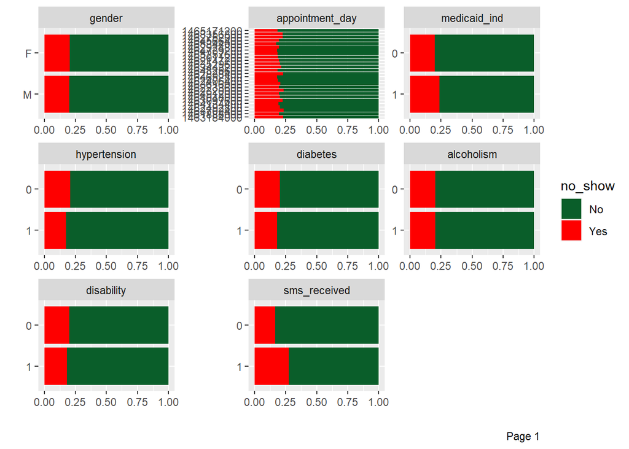

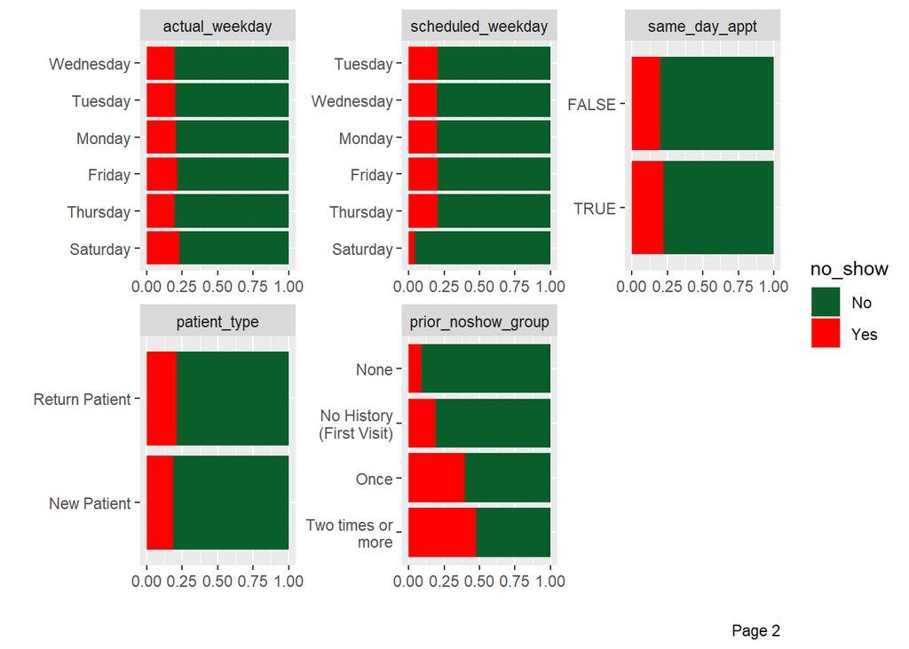

```r
plot_bar(model_data, by = "no_show")
```

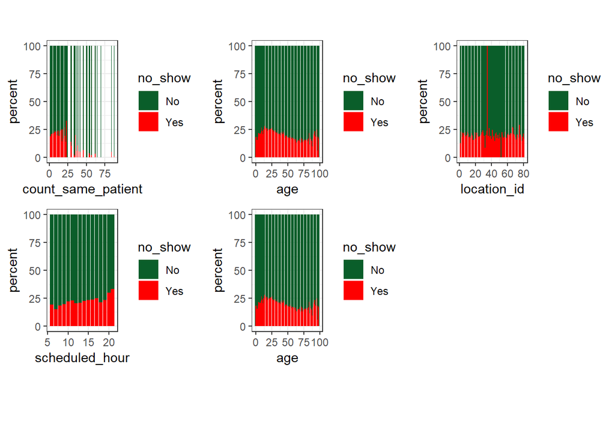

```r
#count_same_patient
# model_data %>%
#   group_by(count_same_patient,no_show)%>%
#   count()%>%
#   group_by(count_same_patient)%>%
#   mutate(percent = n/sum(n)*100,)%>%
#   ungroup() %>%
#   ggplot()+
#   geom_col(aes(x=count_same_patient,y=n, fill=no_show))

p2 <- model_data %>%
  group_by(count_same_patient,no_show)%>%
  count()%>%
  group_by(count_same_patient)%>%
  mutate(percent = n/sum(n)*100,)%>%
  ungroup() %>%
  ggplot()+
  geom_col(aes(x=count_same_patient,y=percent, fill=no_show))

#age
p3 <- model_data %>%
  filter(age<100) %>%
  group_by(age,no_show)%>%
  count()%>%
  group_by(age)%>%
  mutate(percent = n/sum(n)*100,)%>%
  ungroup() %>%
  ggplot()+
  geom_col(aes(x=age,y=percent, fill=no_show))


#location_id
p4 <- model_data %>%
  group_by(location_id,no_show)%>%
  count()%>%
  group_by(location_id)%>%
  mutate(percent = n/sum(n)*100)%>%
  ggplot()+
  geom_col(aes(x=location_id,y=percent,fill=no_show))

#schedule_hour
p5 <- model_data %>%
  group_by(scheduled_hour,no_show)%>%
   count()%>%
   group_by(scheduled_hour)%>%
   mutate(percent = n/sum(n)*100)%>%
   ggplot()+
   geom_col(aes(x=scheduled_hour,y=percent,fill=no_show))


#age
# model_data %>%
#   filter(age<100) %>%
#   group_by(age,no_show)%>%
#   count()%>%
#   group_by(age)%>%
#   mutate(percent = n/sum(n)*100,)%>%
#   ungroup() %>%
#   ggplot()+
#   geom_col(aes(x=age,y=n, fill=no_show))


p6 <- model_data %>%
  filter(age<100) %>%
  group_by(age,no_show)%>%
  count()%>%
  group_by(age)%>%
  mutate(percent = n/sum(n)*100,)%>%
  ungroup() %>%
  ggplot()+
  geom_col(aes(x=age,y=percent, fill=no_show))

# model_data %>%
#   mutate(age_category = ifelse(age<50, "less than 50", "older than 50")) %>% group_by(age_category,no_show)%>%
#   count()%>%
# group_by(age_category)%>%
# mutate(percent = n/sum(n)*100,)

all_plots <- plot_grid(p2,p3,p4,p5,p6)


ggdraw(all_plots, ylim = c(-0.2, 1.1), xlim = c(0, 1), clip = "on")
```

Find most important features:

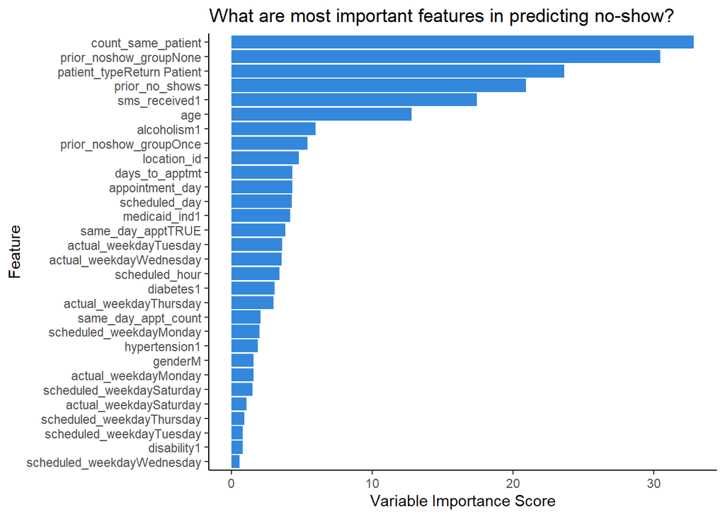

```r
#split the data into the training and testing sets (75% - train, 25% - test)
sample_size <- floor(0.75 * nrow(model_data))

# ensure the results are repeatable
set.seed(123)
train_ind <- sample(seq_len(nrow(model_data)), size = sample_size)

train <- model_data[train_ind, ]
test <- model_data[-train_ind, ]

#Rank Features By Importance

# ensure results are repeatable
set.seed(7)
# load the library
library(caret)
# prepare training scheme
control <- trainControl(method="repeatedcv", number=10, repeats=3)
# train the model
train_data <- train %>%
  select(-c(patient_id))

model <- glm(no_show ~ .,family = binomial, data = train_data)
# estimate variable importance
importance <- varImp(model, scale=FALSE)
# summarize importance
#print(importance %>% arrange(-Overall))

# plot importance
importance <- data.frame(importance) %>%
  mutate(feature = row.names(importance)) %>%
  arrange(Overall)

row.names(importance) <- NULL


ggplot(data = importance, mapping = aes(y = fct_inorder(feature),
                                 x = Overall)) +
  geom_bar(stat='identity',fill = "#3388dd") +
  theme_classic()+
  labs(title = str_wrap("What are most important features in predicting no-show?", width = 70),
    x = "Variable Importance Score",
    y = "Feature"

  )
```

### Create the model

Here I am creating the final model using Logistic Regression:

```r
#########################################################################################
#                                 Create the model                                      #
#########################################################################################

#split the data into the training and testing sets (75% - train, 25% - test)
sample_size <- floor(0.75 * nrow(model_data))

# ensure the results are repeatable
set.seed(123)
train_ind <- sample(seq_len(nrow(model_data)), size = sample_size)

train <- model_data[train_ind, ]
test <- model_data[-train_ind, ]

#create the model
model <- glm(no_show ~sms_received+prior_no_shows+age
             +days_to_apptmt+scheduled_hour+location_id+medicaid_ind,
             family = binomial, data = train)
summary(model) %>% pander()
```

|  | Estimate | Std. Error | z value | Pr(>\|z\|) |
| --- | --- | --- | --- | --- |
| **(Intercept)** | -2.044 | 0.0405 | -50.48 | 0 |
| **sms_received1** | 0.3729 | 0.02009 | 18.56 | 6.755e-77 |
| **prior_no_shows** | 0.6355 | 0.009988 | 63.63 | 0 |
| **age** | -0.007726 | 0.0004089 | -18.89 | 1.306e-79 |
| **days_to_apptmt** | 0.02563 | 0.0005809 | 44.12 | 0 |
| **scheduled_hour** | 0.02312 | 0.002851 | 8.109 | 5.098e-16 |
| **location_id** | -0.001557 | 0.0004241 | -3.672 | 0.0002404 |
| **medicaid_ind1** | 0.1649 | 0.0297 | 5.554 | 2.793e-08 |

(Dispersion parameter for binomial family taken to be 1 )

| Null deviance: | 83553 on 82890 degrees of freedom |
| --- | --- |
| Residual deviance: | 75090 on 82883 degrees of freedom |

Let’s test our model by looking at the confusion matrix:

```r
#########################################################################################
#                                   Test the model                                      #
#########################################################################################

test_response <- predict(model, test, type = "response")

test$test_response <-test_response

evaluate <- test %>%
  mutate(classification = ifelse(test_response > .8, "Predicted Yes", "Predicted No"))


(result <- table(evaluate$no_show, evaluate$classification)) %>% pander()
```

|  | Predicted No | Predicted Yes |
| --- | --- | --- |
| **No** | 22015 | 96 |
| **Yes** | 5365 | 155 |

And the percent correctly classified:

```r
#percent correctly classified:
pcc<- (result[1,1] + result[2,2]) / (result[1,1] + result[1,2] + result[2,1]+result[2,2])

paste0(round(pcc*100,2),"%") %>% pander()
```

80.24%

[^1]: [Development and validation of a patient no-show predictive model at a primary care setting in Southern Brazil](https://pubmed.ncbi.nlm.nih.gov/30947294/)